# Differential Sites

**ℹ️ Input data recapitulation**

Project name : **HCV_Catez**  
RiboClass Name : **ribo_adj_annot**.  
Number of uploaded samples: **42** samples.  
RNA(s) used by the coverage tool: **NR_023363.1_5S, NR_046235.3_5.8S, NR_046235.3_18S, NR_046235.3_28S**  
There are **7217** genomic positions.

**C-score**  
Method of computation : **median**  
Window length : **6**  
**7161** genomic positions with a valid C-score in all samples.  
**ComBat-seq**  
ComBat-seq correction ? **Yes**  
Metadata used for ComBat-seq : **library**

## 0.1 Site-by-site analysis of rRNA 2’Ome // on garde cette partie comme elle est.

The alteration in rRNA 2’Ome is analysed site-by-site individually to identify significant alteration in rRNA 2’Ome level at particular site depending on the biological context. c’est le line plot.

### 0.1.1 Site-by-site analysis of all rRNA 2’Ome sites

Mean comparison of C-score between biological conditions is performed for all rRNA 2’Ome sites.

Here is given a line plot given the mean C-score and the standard deviation for each rRNA 2’Ome sites in the different biological context. Color indicates the different biological groups.

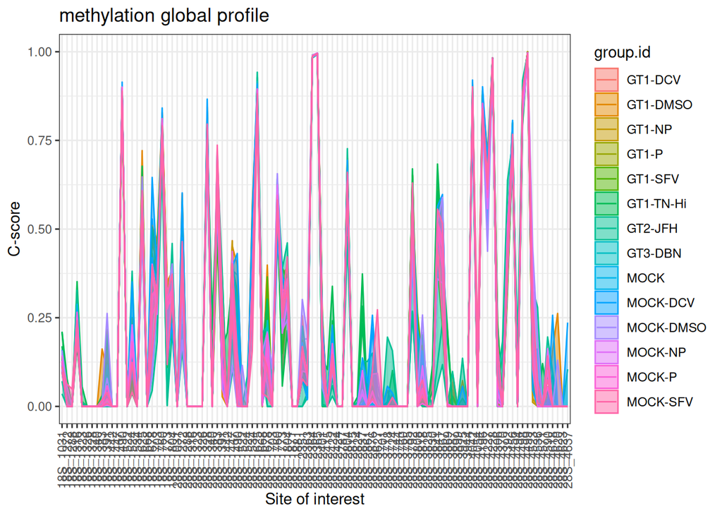

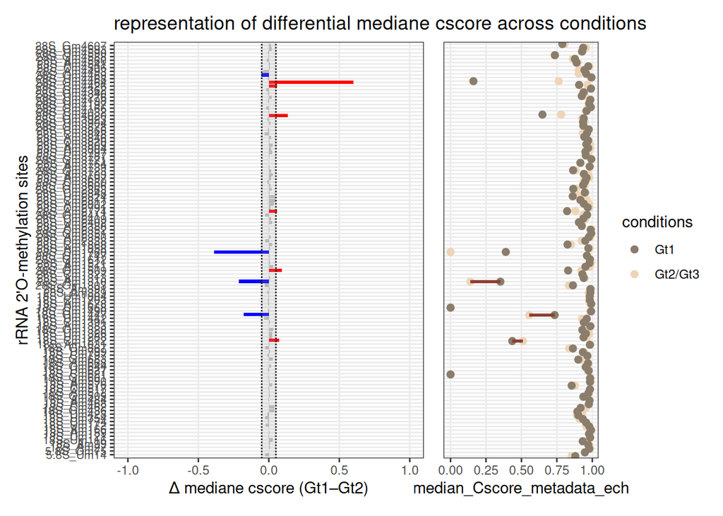

# 1 Site-by-site analysis of rRNA 2’Ome

In this report, the alteration in rRNA 2’Ome is analysed site-by-site individually to identify significant alteration in rRNA 2’Ome level at particular site depending on the biological context.

## 1.1 Site-by-site analysis of all differential rRNA 2’Ome sites

Mean comparison of C-score between biological conditions for significant rRNA 2’Ome sites is shown.

First, mean comparison between biological conditions is performed for all the rRNA 2’Ome sites using non-parametric method of Kruskall Wallis. P-values are adjusted using the false discovery rate (fdr) method.

**Here is given a box plot given the C-score in the different biological context for each rRNA sites whose 2’Ome is significantly different between the biological conditions. Color indicates the different biological groups.**

```
## 2 significant sites found !
```

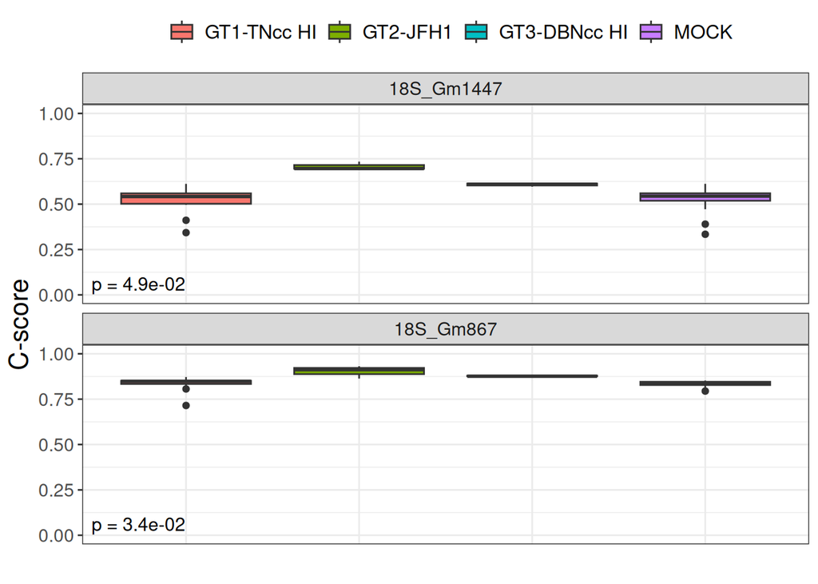

**The following table shows both p-value (adjusted or not) from the Kruskal-Wallis test at each site and the range of conditions’mean for ALL annotated sites :**

```
##           site        p.val        p.adj   range_mean
## 1   18S_Am1031 9.511800e-01 0.9686328668 0.0009538514
## 2   18S_Am1383 6.044052e-01 0.8947316461 0.0002761237
## 3    18S_Am159 5.451395e-01 0.8947316461 0.0031427529
## 4    18S_Am166 2.909278e-01 0.7246610231 0.0023543503
## 5   18S_Am1678 3.936215e-01 0.7634022946 0.0023518789
## 6     18S_Am27 5.713348e-01 0.8947316461 0.0042187460
## 7    18S_Am468 3.161241e-01 0.7246610231 0.0039366400
## 8    18S_Am484 6.818018e-01 0.9056853458 0.0038343715
## 9    18S_Am512 9.102559e-01 0.9570540219 0.0022650397
## 10   18S_Am576 2.723040e-02 0.2900754958 0.0315308886
## 11   18S_Am590 5.060251e-01 0.8795824764 0.0014823617
## 12   18S_Am668 9.427171e-01 0.9686328668 0.0003419424
## 13    18S_Am99 2.502491e-01 0.6944412288 0.0040119848
## 14  18S_Cm1272 3.486717e-02 0.2940344798 0.1797856652
```

[output cut: 98 more lines]